# Tugas 3 APG

Bill Van Ricardo Zalukhu

2022-03-02

```r
library('MVN')
library('mvoutlier')
library('rcompanion')
library('caret')
library('openxlsx')
library('car')
library('RVAideMemoire')
```

```r
milk_tranport <- read.xlsx('C://Users//bilva//OneDrive//Documents//3SI1//Semester 6//Analisis Peubah Ganda//Tugas 3//Milk_Transport.xlsx')
```

## Mendeteksi Outlier Menggunakan Bivariate Scatter Plot, Chi-Square Plot, dan Q-Q Plot Univariate

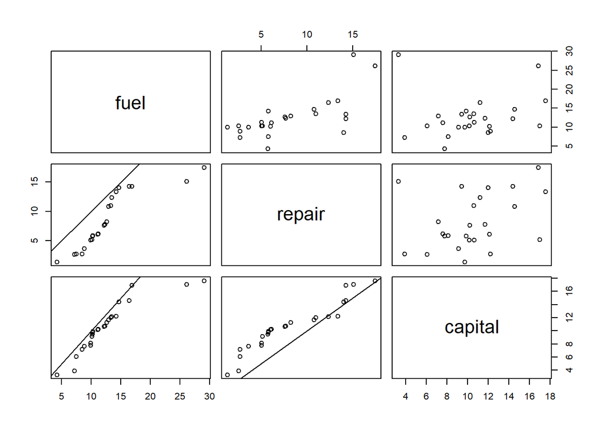

```r
panel.qq <- function(x, y, ...) {
  usr <- par("usr"); on.exit(par(usr))
  par(usr = c(0, 1, 0, 1), new = TRUE)
  qqplot(x, y, xlab = deparse(substitute(x)), ylab = deparse(substitute(y)),
         xaxt = "n", yaxt = "n")
  abline(c(0,1), ...)
}

pairs(milk_tranport, lower.panel = panel.qq)
```

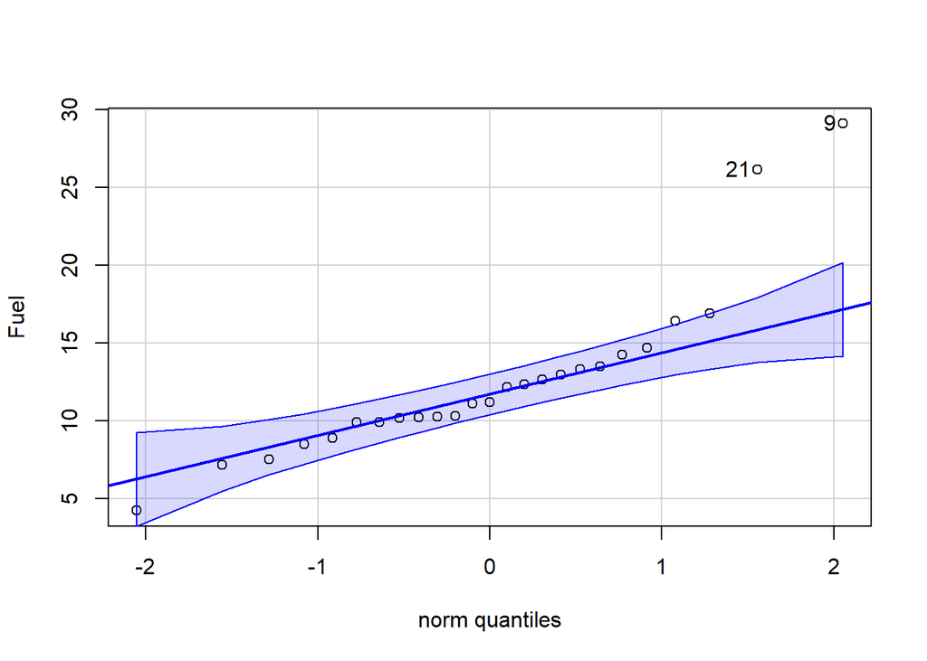

```
## [1]  9 21
```

```r
qqPlot(milk_tranport[, 1], ylab = 'Fuel')
```

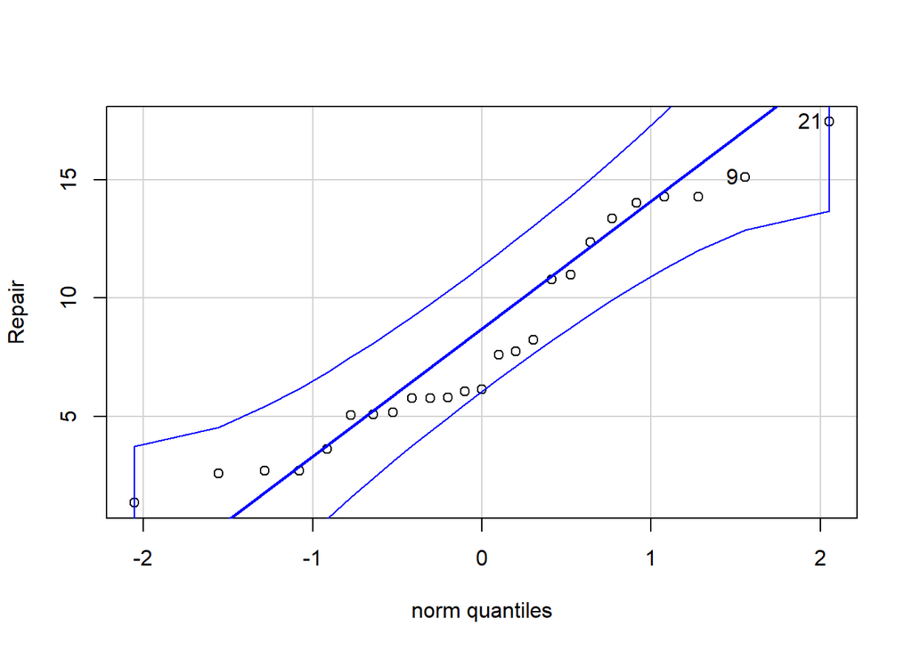

```
## [1] 21  9
```

```r
qqPlot(milk_tranport[, 2], ylab = 'Repair')
```

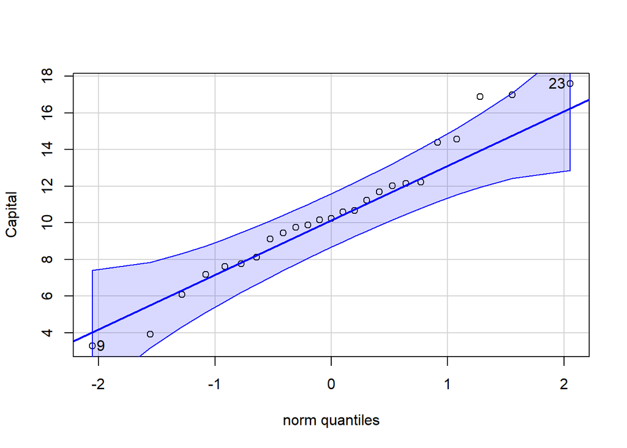

```
## [1]  9 23
```

```r
qqPlot(milk_tranport[, 3], ylab = 'Capital')
```

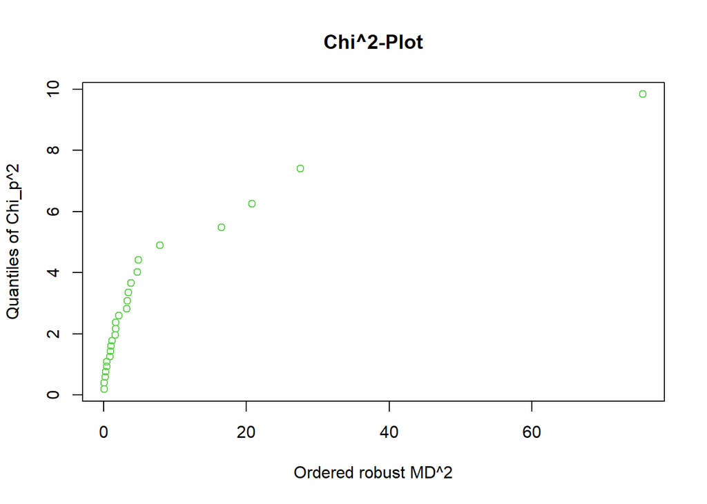

```
## Remove outliers with left-click, stop with right-click on plotting device
```

```r
chisq.plot(milk_tranport)
```

Jika kita melihat dari hasil scatter plot, Chi-Square plot, dan Q-Q plot dari setiap variabel dan/atau kombinasinya, kita bisa melihat bahwa data mengandung outlier. Khususnya untuk variabel `Fuel`, jika kita melihat dari Q-Q plot nya, terlihat bahwa ada outlier pada varabel tersebut.

## Nomor 2: Uji Multivariat Normal pada Data Mentah

1. Henze-Zikler Test

```r
mvn(milk_tranport, showOutliers = T)
```

```
## $multivariateNormality
##            Test        HZ    p value MVN
## 1 Henze-Zirkler 0.9916636 0.01156698  NO
##
## $univariateNormality
##               Test  Variable Statistic   p value Normality
## 1 Anderson-Darling   fuel       1.4744    0.0006    NO
## 2 Anderson-Darling  repair      0.7691    0.0394    NO
## 3 Anderson-Darling  capital     0.3049    0.5434    YES
##
## $Descriptives
##          n    Mean  Std.Dev Median  Min   Max 25th  75th      Skew   Kurtosis
## fuel    25 12.5600 5.382000  11.20 4.24 29.11 9.92 13.50 1.5749453  2.5684509
## repair  25  8.1568 4.628730   6.15 1.35 17.44 5.07 12.34 0.4018015 -1.2088103
## capital 25 10.5444 3.687688  10.23 3.28 17.59 8.13 12.14 0.1154018 -0.4623851
##
## $multivariateOutliers
## NULL
```

2. Mardia Test

```r
mvn(milk_tranport, mvnTest = 'mardia', showOutliers = TRUE)
```

```
## $multivariateNormality
##              Test        Statistic              p value Result
## 1 Mardia Skewness 31.1025625248329 0.000564272658581754     NO
## 2 Mardia Kurtosis  2.6058138034132  0.00916562719177083     NO
## 3             MVN             <NA>                 <NA>     NO
##
## $univariateNormality
##               Test  Variable Statistic   p value Normality
## 1 Anderson-Darling   fuel       1.4744    0.0006    NO
## 2 Anderson-Darling  repair      0.7691    0.0394    NO
## 3 Anderson-Darling  capital     0.3049    0.5434    YES
##
## $Descriptives
##          n    Mean  Std.Dev Median  Min   Max 25th  75th      Skew   Kurtosis
## fuel    25 12.5600 5.382000  11.20 4.24 29.11 9.92 13.50 1.5749453  2.5684509
## repair  25  8.1568 4.628730   6.15 1.35 17.44 5.07 12.34 0.4018015 -1.2088103
## capital 25 10.5444 3.687688  10.23 3.28 17.59 8.13 12.14 0.1154018 -0.4623851
##
## $multivariateOutliers
## NULL
```

3. Royston Test

```r
mvn(milk_tranport, mvnTest = 'royston', showOutliers = TRUE)
```

```
## $multivariateNormality
##      Test       H    p value MVN
## 1 Royston 16.2251 0.00102683  NO
##
## $univariateNormality
##               Test  Variable Statistic   p value Normality
## 1 Anderson-Darling   fuel       1.4744    0.0006    NO
## 2 Anderson-Darling  repair      0.7691    0.0394    NO
## 3 Anderson-Darling  capital     0.3049    0.5434    YES
##
## $Descriptives
##          n    Mean  Std.Dev Median  Min   Max 25th  75th      Skew   Kurtosis
## fuel    25 12.5600 5.382000  11.20 4.24 29.11 9.92 13.50 1.5749453  2.5684509
## repair  25  8.1568 4.628730   6.15 1.35 17.44 5.07 12.34 0.4018015 -1.2088103
## capital 25 10.5444 3.687688  10.23 3.28 17.59 8.13 12.14 0.1154018 -0.4623851
##
## $multivariateOutliers
## NULL
```

4. E-Statistics Test

```r
mvn(milk_tranport, mvnTest = 'energy', showOutliers = T)
```

```
## $multivariateNormality
##          Test Statistic p value MVN
## 1 E-statistic  1.301256   0.001  NO
##
## $univariateNormality
##               Test  Variable Statistic   p value Normality
## 1 Anderson-Darling   fuel       1.4744    0.0006    NO
## 2 Anderson-Darling  repair      0.7691    0.0394    NO
## 3 Anderson-Darling  capital     0.3049    0.5434    YES
##
## $Descriptives
##          n    Mean  Std.Dev Median  Min   Max 25th  75th      Skew   Kurtosis
## fuel    25 12.5600 5.382000  11.20 4.24 29.11 9.92 13.50 1.5749453  2.5684509
## repair  25  8.1568 4.628730   6.15 1.35 17.44 5.07 12.34 0.4018015 -1.2088103
## capital 25 10.5444 3.687688  10.23 3.28 17.59 8.13 12.14 0.1154018 -0.4623851
##
## $multivariateOutliers
## NULL
```

5. Shapiro-Wilk

```r
mshapiro.test(milk_tranport)
```

```
##
##  Multivariate Shapiro-Wilk normality test
##
## data:  (fuel,repair,capital)
## W = 0.77291, p-value = 8.301e-05
```

## Nomor 3: Uji Multivariat Normal Dengan Data yang Telah Diolah

Pada bagian ini, kita akan melakukan uji multivariat normal pada data yang telah diolah sedimikian rupa, sehingga diharapkan data bisa berdistribusi multivariat normal. Untuk penanganan ketidaknormalan, cara yang akan diterapkan adalah membuang observasi yang mengandung outlier dan juga melakukan transformasi pada data mentah.

### 1. Membuang Observasi yang Mengandung Outliers

1.1 Menghapus Variabel yang Mengandung Outlier

```r
milkTranport_clean <- milk_tranport[, c(2, 3)]
```

1. Menggunakan Mardia Test

```r
mvn(milkTranport_clean, mvnTest = 'mardia')
```

```
## $multivariateNormality
##              Test         Statistic           p value Result
## 1 Mardia Skewness  3.34019065147693 0.502589698028303    YES
## 2 Mardia Kurtosis 0.452637801029192 0.650809574392815    YES
## 3             MVN              <NA>              <NA>    YES
##
## $univariateNormality
##               Test  Variable Statistic   p value Normality
## 1 Anderson-Darling  repair      0.7691    0.0394    NO
## 2 Anderson-Darling  capital     0.3049    0.5434    YES
##
## $Descriptives
##          n    Mean  Std.Dev Median  Min   Max 25th  75th      Skew   Kurtosis
## repair  25  8.1568 4.628730   6.15 1.35 17.44 5.07 12.34 0.4018015 -1.2088103
## capital 25 10.5444 3.687688  10.23 3.28 17.59 8.13 12.14 0.1154018 -0.4623851
```

2. Menggunakan Henze-Zikler Test

```r
mvn(milkTranport_clean)
```

```
## $multivariateNormality
##            Test        HZ   p value MVN
## 1 Henze-Zirkler 0.5366546 0.2372122 YES
##
## $univariateNormality
##               Test  Variable Statistic   p value Normality
## 1 Anderson-Darling  repair      0.7691    0.0394    NO
## 2 Anderson-Darling  capital     0.3049    0.5434    YES
##
## $Descriptives
##          n    Mean  Std.Dev Median  Min   Max 25th  75th      Skew   Kurtosis
## repair  25  8.1568 4.628730   6.15 1.35 17.44 5.07 12.34 0.4018015 -1.2088103
## capital 25 10.5444 3.687688  10.23 3.28 17.59 8.13 12.14 0.1154018 -0.4623851
```

3. Menggunakan Royston Test

```r
mvn(milkTranport_clean, mvnTest = 'royston')
```

```
## $multivariateNormality
##      Test        H  p value MVN
## 1 Royston 3.525303 0.172605 YES
##
## $univariateNormality
##               Test  Variable Statistic   p value Normality
## 1 Anderson-Darling  repair      0.7691    0.0394    NO
## 2 Anderson-Darling  capital     0.3049    0.5434    YES
##
## $Descriptives
##          n    Mean  Std.Dev Median  Min   Max 25th  75th      Skew   Kurtosis
## repair  25  8.1568 4.628730   6.15 1.35 17.44 5.07 12.34 0.4018015 -1.2088103
## capital 25 10.5444 3.687688  10.23 3.28 17.59 8.13 12.14 0.1154018 -0.4623851
```

4. Menggunakan E-Statistics Test

```r
mvn(milkTranport_clean, mvnTest = 'energy')
```

```
## $multivariateNormality
##          Test Statistic p value MVN
## 1 E-statistic 0.7161683   0.294 YES
##
## $univariateNormality
##               Test  Variable Statistic   p value Normality
## 1 Anderson-Darling  repair      0.7691    0.0394    NO
## 2 Anderson-Darling  capital     0.3049    0.5434    YES
##
## $Descriptives
##          n    Mean  Std.Dev Median  Min   Max 25th  75th      Skew   Kurtosis
## repair  25  8.1568 4.628730   6.15 1.35 17.44 5.07 12.34 0.4018015 -1.2088103
## capital 25 10.5444 3.687688  10.23 3.28 17.59 8.13 12.14 0.1154018 -0.4623851
```

5. Menggunakan Shapiro-Wilk

```r
mshapiro.test(milkTranport_clean)
```

```
##
##  Multivariate Shapiro-Wilk normality test
##
## data:  (repair,capital)
## W = 0.94094, p-value = 0.1556
```

1.2. Menghapus Elemen Outlier

```r
Q1 <- quantile(milk_tranport$fuel, .25)
Q3 <- quantile(milk_tranport$fuel, .75)
IQR <- (Q3 - Q1)

upper_bound <- Q3 + (IQR * 1.5)
lower_bound <- Q1 - (IQR * 1.5)

eliminated <- subset(milk_tranport, milk_tranport$fuel > lower_bound & milk_tranport$fuel < upper_bound)
```

1. Menggunakan Mardia Test

```r
set.seed(1000)
mvn(eliminated, mvnTest = 'mardia')
```

```
## $multivariateNormality
##              Test           Statistic           p value Result
## 1 Mardia Skewness     9.4882506238583 0.486476132441089    YES
## 2 Mardia Kurtosis -0.0409803065841101 0.967311595741054    YES
## 3             MVN                <NA>              <NA>    YES
##
## $univariateNormality
##               Test  Variable Statistic   p value Normality
## 1 Anderson-Darling   fuel       0.2420    0.7402    YES
## 2 Anderson-Darling  repair      0.6653    0.0712    YES
## 3 Anderson-Darling  capital     0.3077    0.5335    YES
##
## $Descriptives
##          n      Mean  Std.Dev Median  Min   Max  25th    75th      Skew
## fuel    22 11.567727 2.631639 11.155 7.19 16.93 9.985 13.2275 0.2991707
## repair  22  7.528636 4.172076  6.100 1.35 14.27 5.055 10.9300 0.3573765
## capital 22 10.711818 3.273853 10.415 3.92 17.59 9.210 12.1075 0.2338098
##           Kurtosis
## fuel    -0.7512962
## repair  -1.2970384
## capital -0.1871699
```

2. Menggunakan Henze-Zikler Test

```r
set.seed(1000)
mvn(eliminated)
```

```
## $multivariateNormality
##            Test       HZ  p value MVN
## 1 Henze-Zirkler 0.577352 0.468716 YES
##
## $univariateNormality
##               Test  Variable Statistic   p value Normality
## 1 Anderson-Darling   fuel       0.2420    0.7402    YES
## 2 Anderson-Darling  repair      0.6653    0.0712    YES
## 3 Anderson-Darling  capital     0.3077    0.5335    YES
##
## $Descriptives
##          n      Mean  Std.Dev Median  Min   Max  25th    75th      Skew
## fuel    22 11.567727 2.631639 11.155 7.19 16.93 9.985 13.2275 0.2991707
## repair  22  7.528636 4.172076  6.100 1.35 14.27 5.055 10.9300 0.3573765
## capital 22 10.711818 3.273853 10.415 3.92 17.59 9.210 12.1075 0.2338098
##           Kurtosis
## fuel    -0.7512962
## repair  -1.2970384
## capital -0.1871699
```

3. Menggunakan Royston Test

```r
set.seed(1000)
mvn(eliminated, mvnTest = 'royston')
```

```
## $multivariateNormality
##      Test        H   p value MVN
## 1 Royston 3.868183 0.2868071 YES
##
## $univariateNormality
##               Test  Variable Statistic   p value Normality
## 1 Anderson-Darling   fuel       0.2420    0.7402    YES
## 2 Anderson-Darling  repair      0.6653    0.0712    YES
## 3 Anderson-Darling  capital     0.3077    0.5335    YES
##
## $Descriptives
##          n      Mean  Std.Dev Median  Min   Max  25th    75th      Skew
## fuel    22 11.567727 2.631639 11.155 7.19 16.93 9.985 13.2275 0.2991707
## repair  22  7.528636 4.172076  6.100 1.35 14.27 5.055 10.9300 0.3573765
## capital 22 10.711818 3.273853 10.415 3.92 17.59 9.210 12.1075 0.2338098
##           Kurtosis
## fuel    -0.7512962
## repair  -1.2970384
## capital -0.1871699
```

4. Menggunakan E-Statistics Test

```r
set.seed(1000)
mvn(eliminated, mvnTest = 'energy')
```

```
## $multivariateNormality
##          Test Statistic p value MVN
## 1 E-statistic 0.8384261   0.382 YES
##
## $univariateNormality
##               Test  Variable Statistic   p value Normality
## 1 Anderson-Darling   fuel       0.2420    0.7402    YES
## 2 Anderson-Darling  repair      0.6653    0.0712    YES
## 3 Anderson-Darling  capital     0.3077    0.5335    YES
##
## $Descriptives
##          n      Mean  Std.Dev Median  Min   Max  25th    75th      Skew
## fuel    22 11.567727 2.631639 11.155 7.19 16.93 9.985 13.2275 0.2991707
## repair  22  7.528636 4.172076  6.100 1.35 14.27 5.055 10.9300 0.3573765
## capital 22 10.711818 3.273853 10.415 3.92 17.59 9.210 12.1075 0.2338098
##           Kurtosis
## fuel    -0.7512962
## repair  -1.2970384
## capital -0.1871699
```

5. Menggunakan Shapiro-Wilk

```r
mshapiro.test(eliminated)
```

```
##
##  Multivariate Shapiro-Wilk normality test
##
## data:  (fuel,repair,capital)
## W = 0.87158, p-value = 0.008379
```

## 2. Melakukan Transformasi Data

```r
milkTranport_temp <- car::powerTransform(object = cbind(fuel, repair, capital) ~ 1, data = milk_tranport)

milkTranport_tf <- data.frame()

for(i in c(1:3)){
  for(j in c(1:25))
    milkTranport_tf[j,i] <- (milk_tranport[j,i]^(milkTranport_temp$lambda[i])-1)/(milkTranport_temp$lambda[i])
}
```

1. Menggunakan Mardia Test

```r
set.seed(1000)
mvn(milkTranport_tf, mvnTest = 'mardia')
```

```
## $multivariateNormality
##              Test        Statistic            p value Result
## 1 Mardia Skewness 20.3295528904037 0.0262853199200447     NO
## 2 Mardia Kurtosis 1.70742158327139 0.0877437215366992    YES
## 3             MVN             <NA>               <NA>     NO
##
## $univariateNormality
##               Test  Variable Statistic   p value Normality
## 1 Anderson-Darling    V1        0.6355    0.0864    YES
## 2 Anderson-Darling    V2        0.5134    0.1752    YES
## 3 Anderson-Darling    V3        0.3011    0.5526    YES
##
## $Descriptives
##     n     Mean   Std.Dev   Median       Min       Max     25th      75th
## V1 25 3.075279 0.5997343 2.995621 1.6399749  4.568976 2.813602  3.283283
## V2 25 3.987912 2.0418939 3.299464 0.3289599  7.634779 2.754635  5.885692
## V3 25 9.208589 3.5086979 8.922925 2.2455681 15.879669 6.920595 10.736334
##          Skew   Kurtosis
## V1 0.38244253  0.9893993
## V2 0.11373486 -1.2194294
## V3 0.09544995 -0.4571206
```

2. Menggunakan Henze-Zikler Test

```r
set.seed(1000)
mvn(milkTranport_tf)
```

```
## $multivariateNormality
##            Test        HZ   p value MVN
## 1 Henze-Zirkler 0.7179034 0.1825952 YES
##
## $univariateNormality
##               Test  Variable Statistic   p value Normality
## 1 Anderson-Darling    V1        0.6355    0.0864    YES
## 2 Anderson-Darling    V2        0.5134    0.1752    YES
## 3 Anderson-Darling    V3        0.3011    0.5526    YES
##
## $Descriptives
##     n     Mean   Std.Dev   Median       Min       Max     25th      75th
## V1 25 3.075279 0.5997343 2.995621 1.6399749  4.568976 2.813602  3.283283
## V2 25 3.987912 2.0418939 3.299464 0.3289599  7.634779 2.754635  5.885692
## V3 25 9.208589 3.5086979 8.922925 2.2455681 15.879669 6.920595 10.736334
##          Skew   Kurtosis
## V1 0.38244253  0.9893993
## V2 0.11373486 -1.2194294
## V3 0.09544995 -0.4571206
```

3. Menggunakan Royston Test

```r
set.seed(1000)
mvn(milkTranport_tf, mvnTest = 'royston')
```

```
## $multivariateNormality
##      Test        H   p value MVN
## 1 Royston 4.990325 0.1757107 YES
##
## $univariateNormality
##               Test  Variable Statistic   p value Normality
## 1 Anderson-Darling    V1        0.6355    0.0864    YES
## 2 Anderson-Darling    V2        0.5134    0.1752    YES
## 3 Anderson-Darling    V3        0.3011    0.5526    YES
##
## $Descriptives
##     n     Mean   Std.Dev   Median       Min       Max     25th      75th
## V1 25 3.075279 0.5997343 2.995621 1.6399749  4.568976 2.813602  3.283283
## V2 25 3.987912 2.0418939 3.299464 0.3289599  7.634779 2.754635  5.885692
## V3 25 9.208589 3.5086979 8.922925 2.2455681 15.879669 6.920595 10.736334
##          Skew   Kurtosis
## V1 0.38244253  0.9893993
## V2 0.11373486 -1.2194294
## V3 0.09544995 -0.4571206
```

4. Menggunakan E-Statistics Test

```r
set.seed(1000)
mvn(milkTranport_tf, mvnTest = 'energy')
```

```
## $multivariateNormality
##          Test Statistic p value MVN
## 1 E-statistic 0.9914692   0.083 YES
##
## $univariateNormality
##               Test  Variable Statistic   p value Normality
## 1 Anderson-Darling    V1        0.6355    0.0864    YES
## 2 Anderson-Darling    V2        0.5134    0.1752    YES
## 3 Anderson-Darling    V3        0.3011    0.5526    YES
##
## $Descriptives
##     n     Mean   Std.Dev   Median       Min       Max     25th      75th
## V1 25 3.075279 0.5997343 2.995621 1.6399749  4.568976 2.813602  3.283283
## V2 25 3.987912 2.0418939 3.299464 0.3289599  7.634779 2.754635  5.885692
## V3 25 9.208589 3.5086979 8.922925 2.2455681 15.879669 6.920595 10.736334
##          Skew   Kurtosis
## V1 0.38244253  0.9893993
## V2 0.11373486 -1.2194294
## V3 0.09544995 -0.4571206
```

5. Menggunakan Shapiro-Wilk

```r
mshapiro.test(milkTranport_tf)
```

```
##
##  Multivariate Shapiro-Wilk normality test
##
## data:  (V1,V2,V3)
## W = 0.84439, p-value = 0.001381
```

Dari beberapa poin di atas, kita dapat mengambil kesimpulan:

- data secar natural (tanpa adanya pengolahan lanjutan) tidak berdistribusi multivariat normal;
- uji multivariat normal sensitif terhadap data outlier;
- uji Mardia berkemungkinan besar sensitif terhadap data outlier (terlihat dari 2 hasil deteksi kenormalan pada data yang belum dibersihkan outliernya dan data yang telah dinormalisasi namun outlier nya belum diatasi);
- ada kemungkinan variabel yang mengandung outlier (dalam hal ini variabel Fuel) membuat hasil dari test multivariat Shapiro-Wilk membuat hasil pengujian tidak multivariat normal ketika tidak dihapus.